# Study of School Academic Performance

cindyst2, trapido2, bching3, rjs8

07/30/2018

```r
install.packages("foreign")
```

```r
library(foreign)
library(lmtest)
library(faraway)
library(MASS)
```

# Introduction

## Background

As part of California’s accountability program, the state Deptarment of Education measures student academic performance and its growth. To achieve this goal, from 1999-2013, the California Department of Education annually calculated the Academic Performance Index (API) for all public schools. These data sets are publicly available at the California Department of Education web site, https://www.cde.ca.gov/ta/ac/ap/apidatafiles.asp.

## Dataset Description

In addition to API scores, the dataset contains the school’s name, district, type (charter or not), student demographics, subject end of year test score averages, ranking in the state, class sizes, average parental education levels, and teacher credentials.

## Interest

We would like to find out which factors predict the academic performance of a school. We are particularly interested to determine whether the fact that the school is a charter school helps the school achieve higher API. Interest in this dataset is driven by the current administration’s Education Secretary’s push to increase the number of charter schools.

# Methodology

We will use API scores as our response. Since we are observing 2004, 2007, 2010, and 2013, we will use the API scores from these respective years as our response. We will build a model base on data from one year and see how well it predicts API scores from other years.

# Cleaning the data

```r
schl2004 = read.dbf("data/api04gdb.dbf", as.is = TRUE)
schl2007 = read.dbf("data/api07gdb.dbf", as.is = TRUE)
schl2010 = read.dbf("data/api10gdb.dbf", as.is = TRUE)
schl2013 = read.dbf("data/api13gdb.dbf", as.is = TRUE)
```

We also create a few helper functions:

```r
#Helper function to remove columns by name (also works on part of column name)
remove_columns = function(dframe, columns_to_remove){
  dframe[-grep(paste(columns_to_remove, collapse = "|"), names(dframe), ignore.case = TRUE)]
}
```

```r
#Helper function to run diagnostics
diagnostics = function(model, pcol = "grey", lcol = "dodgerblue", alpha = 0.05,
                       plotit = TRUE, testit = TRUE) {

  if (plotit == TRUE) {

    # side-by-side plots (one row, two columns)
    par(mfrow = c(1, 2))

    # fitted versus residuals
    plot(fitted(model), resid(model),
         col = pcol, pch = 20, cex = 1.5,
         xlab = "Fitted", ylab = "Residuals",
         main = "Fitted versus Residuals")
    abline(h = 0, col = lcol, lwd = 2)
    grid()

    # qq-plot
    qqnorm(resid(model), col = pcol, pch = 20, cex = 1.5)
    qqline(resid(model), col = lcol, lwd = 2)
    grid()
  }

  if (testit == TRUE) {
    p_val_bp = bptest(model)$p.value
    decision_bp = ifelse(p_val_bp < alpha, "Fail BP test", "Pass BP test")
    residuals = resid(model)
    if(length(residuals) > 5000){
      residuals = residuals[1:5000]
    }

    p_val_shapiro = shapiro.test(residuals)$p.value
    decision_shapiro = ifelse(p_val_shapiro < alpha, "Fail Shapiro-Wilk test", "Pass Shapiro-Wilk test")
    list(p_val_shapiro = p_val_shapiro, decision_shapiro = decision_shapiro, p_val_bp = p_val_bp, decision_bp = decision_bp)
  }
}
```

```r
create_subset = function(df, year){
  cols_to_keep = c(paste0("API",year),"CHARTER", "SIZE", "RTYPE", "PCT_AA","PCT_AI","PCT_AS","PCT_FI","PCT_HI","PCT_PI","PCT_WH","MEALS","P_GATE","P_MIGED","P_EL","P_RFEP","P_DI","YR_RND","CBMOB","DMOB","ACS_K3","ACS_46","ACS_CORE","NOT_HSG","HSG","SOME_COL","COL_GRAD", "GRAD_SCH","AVG_ED","FULL","EMER")
  df = subset(df, select = c(cols_to_keep))
}
```

```r
cleanup = function(df){
  # Remove schools with SIZE = S or T which indicate non-valid API scores

  df = subset(df, subset = !(df$SIZE %in% c("S","T")), select =!(colnames(df) %in% c('SIZE')))

  #We are only interested in looking at data at the school level, so removing rows related to district and   state data
  df= subset(df, subset = (df$RTYPE == "S"), select =!(colnames(df) %in% c('RTYPE')))

  # Remove rows with YR_RND = Yes because they have mostly NA columns
  df = subset(df, subset = (df$YR_RND != 'Yes'), select =!(colnames(df) %in% c('YR_RND')))

  #Remove rows with invalid data for parent education ("0" is most likely missing data)
  df = subset(df, subset = AVG_ED != 0)


}
```

```r
convert_to_numeric = function(dframe, columns_to_numeric) {
  for(col in columns_to_numeric) {
    if(col %in% colnames(dframe)) {
      dframe[, col] = as.numeric(dframe[, col])
    }
  }
  dframe
}
```

The dataset contains a lot of fields related to the calculation of API (target API, growth API) and its components (various subject tests), and also school ranks. These variables are highly correlated with our response variable, so we will remove them. We will also remove fields containing school, district and county names, school type, schoold code, and percent of enrollments.

```r
data_2004 = subset(schl2004, select = c("API04","RTYPE","PCT_AA","PCT_AI","PCT_AS","PCT_FI","PCT_HI","PCT_PI","PCT_WH","MEALS","CBMOB","DMOB","ACS_K3","ACS_46","ACS_CORE","NOT_HSG","HSG","SOME_COL","COL_GRAD", "GRAD_SCH","AVG_ED","FULL","EMER", "YR_RND"))
data_2007 = create_subset(schl2007, "07")
data_2010 = create_subset(schl2010, "10")
data_2013 = create_subset(schl2013, "13")
```

```r
#Remove observations that have missing API scores
data_2004 = data_2004[complete.cases(data_2004$API04),]
data_2007 = data_2007[complete.cases(data_2007$API07),]
data_2010 = data_2010[complete.cases(data_2010$API10),]
data_2013 = data_2013[complete.cases(data_2013$API13),]
# Remove rows with YR_RND = Yes because they have mostly NA columns
data_2004 = subset(data_2004, subset = (data_2004$YR_RND != 'Yes'), select =!(colnames(data_2004) %in% c('YR_RND')))
#Remove rows with invalid data for parent education ("0" is most likely missing data)
data_2004 = subset(data_2004, subset = AVG_ED != 0)
data_2007 = cleanup(data_2007)
data_2010 = cleanup(data_2010)
data_2013 = cleanup(data_2013)
```

We convert CHARTER into factor. Additionally, we change factor levels for “CHARTER” variable: we code direct funded and charter (“D” and “C” in the original dataset) as “Y”, and non-charter (“N/A” in the original dataset) as “N”.

```r
data_2007$CHARTER = as.factor(ifelse(is.na(data_2007$CHARTER), "N", "Y"))
data_2010$CHARTER = as.factor(ifelse(is.na(data_2010$CHARTER), "N", "Y"))
data_2013$CHARTER = as.factor(ifelse(is.na(data_2013$CHARTER), "N", "Y"))
```

The rest of the variables in our set are numeric:

```r
common_cols = c("PCT_AA","PCT_AI","PCT_AS","PCT_FI","PCT_HI","PCT_PI","PCT_WH","MEALS","CBMOB","DMOB","ACS_K3","ACS_46","ACS_CORE","NOT_HSG","HSG","SOME_COL","COL_GRAD", "GRAD_SCH","AVG_ED","FULL","EMER")
all_cols = c(common_cols, "P_GATE","P_MIGED","P_EL","P_RFEP","P_DI")
data_2004 = convert_to_numeric(data_2004, c("API04", common_cols))
data_2007 = convert_to_numeric(data_2007, c("API07", all_cols))
data_2010 = convert_to_numeric(data_2010, c("API10", all_cols))
data_2013 = convert_to_numeric(data_2013, c("API13", all_cols))
```

```r
str(data_2013)
```

```
## 'data.frame':    7966 obs. of  28 variables:
##  $ API13   : num  781 669 792 743 748 560 925 808 838 808 ...
##  $ CHARTER : Factor w/ 2 levels "N","Y": 2 2 2 2 2 1 1 1 2 2 ...
##  $ PCT_AA  : num  9 45 31 19 6 10 7 29 14 25 ...
##  $ PCT_AI  : num  1 2 0 0 1 1 0 1 1 0 ...
##  $ PCT_AS  : num  20 2 1 2 1 7 46 23 15 12 ...
##  $ PCT_FI  : num  2 1 1 0 0 3 9 7 3 15 ...
##  $ PCT_HI  : num  12 41 66 70 90 44 16 17 17 17 ...
##  $ PCT_PI  : num  2 1 0 5 0 0 2 2 0 2 ...
##  $ PCT_WH  : num  53 5 0 1 1 33 18 18 35 24 ...
##  $ MEALS   : num  46 72 75 96 83 91 30 68 27 57 ...
##  $ P_GATE  : num  0 0 0 0 0 0 13 1 0 11 ...
##  $ P_MIGED : num  0 0 0 0 0 0 0 0 0 0 ...
##  $ P_EL    : num  19 12 22 51 63 0 4 33 16 17 ...
##  $ P_RFEP  : num  24 24 26 14 14 0 37 7 3 13 ...
##  $ P_DI    : num  8 9 8 6 5 100 1 11 12 10 ...
##  $ CBMOB   : num  91 95 96 95 85 94 98 94 97 97 ...
##  $ DMOB    : num  91 95 96 95 85 94 100 95 98 98 ...
##  $ ACS_K3  : num  16 NA 23 23 20 5 NA 22 22 NA ...
##  $ ACS_46  : num  16 NA 30 30 26 6 NA 32 25 27 ...
##  $ ACS_CORE: num  10 28 24 NA NA 7 22 NA 22 24 ...
##  $ NOT_HSG : num  7 26 22 39 44 18 9 10 3 6 ...
##  $ HSG     : num  13 26 33 39 33 20 16 30 8 23 ...
##  $ SOME_COL: num  25 33 28 17 14 31 25 30 29 26 ...
##  $ COL_GRAD: num  30 11 12 3 6 14 34 22 33 31 ...
##  $ GRAD_SCH: num  25 3 6 2 2 17 15 8 27 14 ...
##  $ AVG_ED  : num  3.54 2.39 2.47 1.91 1.9 2.91 3.28 2.88 3.75 3.22 ...
##  $ FULL    : num  100 92 100 93 94 99 100 100 100 100 ...
##  $ EMER    : num  10 23 13 11 18 2 0 0 0 4 ...
```

```r
dim(data_2004)
```

```
## [1] 7106   23
```

```r
dim(data_2007)
```

```
## [1] 7191   28
```

```r
dim(data_2010)
```

```
## [1] 7647   28
```

```r
dim(data_2013)
```

```
## [1] 7966   28
```

We will check the percentage of missing values in each dataset:

```r
sapply(data_2004, function(x) mean (is.na(x)))
```

```
##    API04    RTYPE   PCT_AA   PCT_AI   PCT_AS   PCT_FI   PCT_HI   PCT_PI
##  0.00000  0.00000  0.00000  0.00000  0.00000  0.00000  0.00000  0.00000
##   PCT_WH    MEALS    CBMOB     DMOB   ACS_K3   ACS_46 ACS_CORE  NOT_HSG
##  0.00000  0.00000  0.00000  0.00000  0.34253  0.24064  0.66113  0.03026
##      HSG SOME_COL COL_GRAD GRAD_SCH   AVG_ED     FULL     EMER
##  0.03026  0.03026  0.03026  0.03026  0.03026  0.00197  0.00197
```

```r
sapply(data_2007, function(x) mean (is.na(x)))
```

```
##    API07  CHARTER   PCT_AA   PCT_AI   PCT_AS   PCT_FI   PCT_HI   PCT_PI
##   0.0000   0.0000   0.0000   0.0000   0.0000   0.0000   0.0000   0.0000
##   PCT_WH    MEALS   P_GATE  P_MIGED     P_EL   P_RFEP     P_DI    CBMOB
##   0.0000   0.0000   0.0000   0.0000   0.0000   0.0000   0.0000   0.0000
##     DMOB   ACS_K3   ACS_46 ACS_CORE  NOT_HSG      HSG SOME_COL COL_GRAD
##   0.0000   0.3415   0.2201   0.6302   0.0000   0.0000   0.0000   0.0000
## GRAD_SCH   AVG_ED     FULL     EMER
##   0.0000   0.0000   0.0000   0.0000
```

```r
sapply(data_2010, function(x) mean (is.na(x)))
```

```
##    API10  CHARTER   PCT_AA   PCT_AI   PCT_AS   PCT_FI   PCT_HI   PCT_PI
##        0        0        0        0        0        0        0        0
##   PCT_WH    MEALS   P_GATE  P_MIGED     P_EL   P_RFEP     P_DI    CBMOB
##        0        0        0        0        0        0        0        0
##     DMOB   ACS_K3   ACS_46 ACS_CORE  NOT_HSG      HSG SOME_COL COL_GRAD
##        0        1        1        1        0        0        0        0
## GRAD_SCH   AVG_ED     FULL     EMER
##        0        0        1        1
```

```r
sapply(data_2013, function(x) mean (is.na(x)))
```

```
##    API13  CHARTER   PCT_AA   PCT_AI   PCT_AS   PCT_FI   PCT_HI   PCT_PI
##   0.0000   0.0000   0.0000   0.0000   0.0000   0.0000   0.0000   0.0000
##   PCT_WH    MEALS   P_GATE  P_MIGED     P_EL   P_RFEP     P_DI    CBMOB
##   0.0000   0.0000   0.0000   0.0000   0.0000   0.0000   0.0000   0.0000
##     DMOB   ACS_K3   ACS_46 ACS_CORE  NOT_HSG      HSG SOME_COL COL_GRAD
##   0.0000   0.3255   0.2106   0.6067   0.0000   0.0000   0.0000   0.0000
## GRAD_SCH   AVG_ED     FULL     EMER
##   0.0000   0.0000   0.0000   0.0000
```

Average class size fields (ACS_K3, ACS_46, ACS_CORE) have a large percent of missing values, so we will have to remove them. We also know that average education variable is correlated with the other parent education variables, so we will not include it.

```r
data_2007 = remove_columns(data_2007, c('ACS_', 'AVG_ED'))
data_2010 = remove_columns(data_2010, c('ACS_', 'AVG_ED', 'FULL', 'EMER')) #Also removing full and emergency credentials, since they have a lot of missing data
data_2013 = remove_columns(data_2013, c('ACS_', 'AVG_ED'))
```

## Building the model

We will use backward AIC selection:

```r
mod_full = lm(API13 ~ ., data = data_2013)
mod_back_aic = step(mod_full, trace = 0)
summary(mod_back_aic)
```

```
##
## Call:
## lm(formula = API13 ~ CHARTER + PCT_AA + PCT_AI + PCT_AS + PCT_HI +
##     PCT_PI + P_GATE + P_MIGED + P_EL + P_RFEP + P_DI + CBMOB +
##     DMOB + NOT_HSG + HSG + COL_GRAD + GRAD_SCH + EMER, data = data_2013)
##
## Residuals:
##     Min      1Q  Median      3Q     Max
## -313.50  -25.65    1.72   26.31  230.28
##
## Coefficients:
##             Estimate Std. Error t value Pr(>|t|)
## (Intercept) 427.9277    14.6247   29.26  < 2e-16 ***
## CHARTERY      5.1787     1.7845    2.90   0.0037 **
## PCT_AA       -0.9781     0.0550  -17.77  < 2e-16 ***
## PCT_AI       -1.7567     0.2090   -8.40  < 2e-16 ***
## PCT_AS        0.9286     0.0551   16.86  < 2e-16 ***
## PCT_HI        0.3058     0.0424    7.21  6.2e-13 ***
## PCT_PI       -3.0136     0.5065   -5.95  2.8e-09 ***
## P_GATE        0.3809     0.0541    7.04  2.0e-12 ***
## P_MIGED      -0.8975     0.1363   -6.58  4.9e-11 ***
## P_EL         -0.1453     0.0547   -2.66   0.0079 **
## P_RFEP       -0.6706     0.0685   -9.79  < 2e-16 ***
## P_DI         -0.9784     0.0709  -13.80  < 2e-16 ***
## CBMOB         4.7644     0.1900   25.07  < 2e-16 ***
## DMOB         -0.5724     0.2609   -2.19   0.0283 *
## NOT_HSG      -1.2774     0.0818  -15.62  < 2e-16 ***
## HSG          -0.6231     0.0983   -6.34  2.5e-10 ***
## COL_GRAD      0.8387     0.1003    8.36  < 2e-16 ***
## GRAD_SCH      1.0298     0.0679   15.17  < 2e-16 ***
## EMER         -0.8087     0.1433   -5.64  1.7e-08 ***
## ---
## Signif. codes:  0 '***' 0.001 '**' 0.01 '*' 0.05 '.' 0.1 ' ' 1
##
## Residual standard error: 43.6 on 7947 degrees of freedom
## Multiple R-squared:  0.719,  Adjusted R-squared:  0.718
## F-statistic: 1.13e+03 on 18 and 7947 DF,  p-value: <2e-16
```

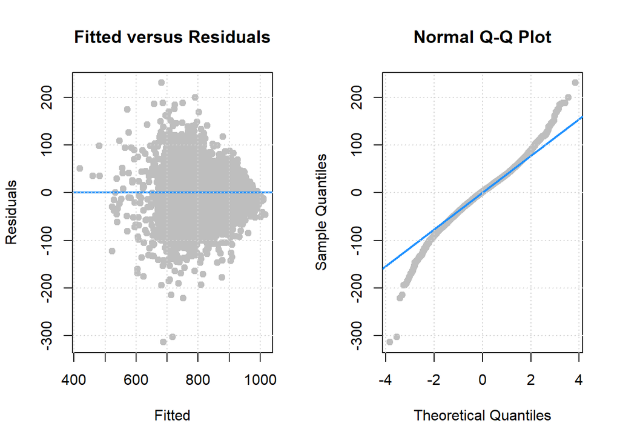

```
## $p_val_shapiro
## [1] 1.354e-24
##
## $decision_shapiro
## [1] "Fail Shapiro-Wilk test"
##
## $p_val_bp
##         BP
## 3.417e-134
##
## $decision_bp
##             BP
## "Fail BP test"
```

```r
diagnostics(mod_back_aic)
```

The tests for normality fail, so we should see how we can transform the model.

We look at the `pairs` plot to see if any of the predictors are collinear. The output has been commented out for brevity for `pairs` charts that didn’t show any relationships.

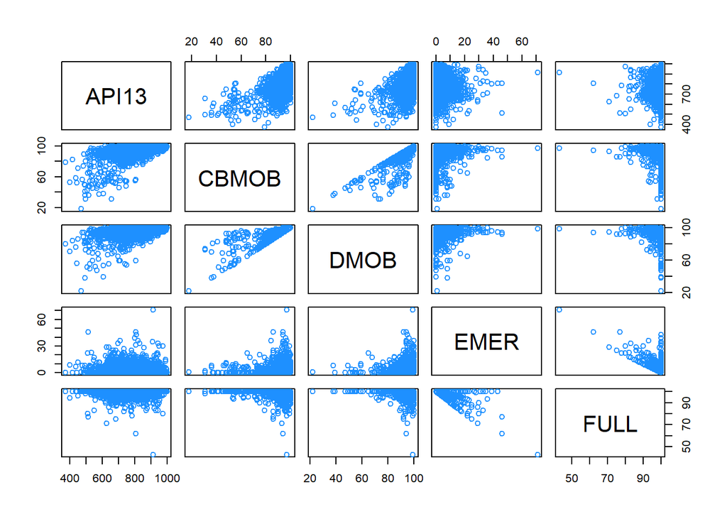

```r
#pairs(subset(data_2013, select=c('API13', 'PCT_AA', 'PCT_AI', 'PCT_AS', 'PCT_FI', 'PCT_HI','PCT_WH')), col = "dodgerblue")
#pairs(subset(data_2013,select=c('API13', 'MEALS', 'P_MIGED', 'P_DI', 'P_GATE')), col = "dodgerblue")
#pairs(subset(data_2013,select=c('API13', 'NOT_HSG', 'HSG', 'SOME_COL', 'GRAD_SCH', )), col = "dodgerblue"))
pairs(subset(data_2013,select=c('API13', 'CBMOB', 'DMOB','EMER', 'FULL')), col = "dodgerblue")
```

```r
cor_matrix = cor(subset(data_2013, select=-c(2)))
(max_val = max(cor_matrix[upper.tri(cor_matrix)]))
```

```
## [1] 0.8645
```

```r
(which(cor_matrix == max_val, arr.ind = TRUE))
```

```
##       row col
## DMOB   16  15
## CBMOB  15  16
```

It looks like the following fields may be collinear: DMOB with CBMOB (which the “cor” function confirms, these two columns have the highest collinearity), so we will remove one of them, DMOB (district mobility). We also need to make sure not to include all the ethnic groups as predictors, because they will be highly collinear (as they add up to 100%). There is also some collinearity between FULL and EMER (percentage of teachers with full and emergency credentials).

```r
mod_reduced = lm(API13 ~ CHARTER + PCT_AA + PCT_AI + PCT_AS + PCT_HI + PCT_PI +
    P_GATE + P_MIGED + P_EL + P_RFEP + P_DI + CBMOB +
    NOT_HSG + SOME_COL + HSG + COL_GRAD + GRAD_SCH + EMER, data = data_2013)
summary(mod_reduced)
```

```
##
## Call:
## lm(formula = API13 ~ CHARTER + PCT_AA + PCT_AI + PCT_AS + PCT_HI +
##     PCT_PI + P_GATE + P_MIGED + P_EL + P_RFEP + P_DI + CBMOB +
##     NOT_HSG + SOME_COL + HSG + COL_GRAD + GRAD_SCH + EMER, data = data_2013)
##
## Residuals:
##    Min     1Q Median     3Q    Max
## -309.7  -25.7    1.7   26.4  229.7
##
## Coefficients:
##             Estimate Std. Error t value Pr(>|t|)
## (Intercept) 429.2299    75.6775    5.67  1.5e-08 ***
## CHARTERY      5.2440     1.7852    2.94   0.0033 **
## PCT_AA       -0.9874     0.0549  -17.99  < 2e-16 ***
## PCT_AI       -1.7535     0.2091   -8.39  < 2e-16 ***
## PCT_AS        0.9271     0.0551   16.82  < 2e-16 ***
## PCT_HI        0.2986     0.0423    7.06  1.8e-12 ***
## PCT_PI       -2.9964     0.5066   -5.92  3.5e-09 ***
## P_GATE        0.3754     0.0540    6.95  4.1e-12 ***
## P_MIGED      -0.8757     0.1361   -6.44  1.3e-10 ***
## P_EL         -0.1423     0.0547   -2.60   0.0093 **
## P_RFEP       -0.6792     0.0685   -9.92  < 2e-16 ***
## P_DI         -0.9690     0.0708  -13.69  < 2e-16 ***
## CBMOB         4.4154     0.1040   42.46  < 2e-16 ***
## NOT_HSG      -1.5100     0.7519   -2.01   0.0446 *
## SOME_COL     -0.2248     0.7525   -0.30   0.7652
## HSG          -0.8430     0.7525   -1.12   0.2626
## COL_GRAD      0.6048     0.7525    0.80   0.4216
## GRAD_SCH      0.7969     0.7521    1.06   0.2894
## EMER         -0.8081     0.1434   -5.64  1.8e-08 ***
## ---
## Signif. codes:  0 '***' 0.001 '**' 0.01 '*' 0.05 '.' 0.1 ' ' 1
##
## Residual standard error: 43.6 on 7947 degrees of freedom
## Multiple R-squared:  0.719,  Adjusted R-squared:  0.718
## F-statistic: 1.13e+03 on 18 and 7947 DF,  p-value: <2e-16
```

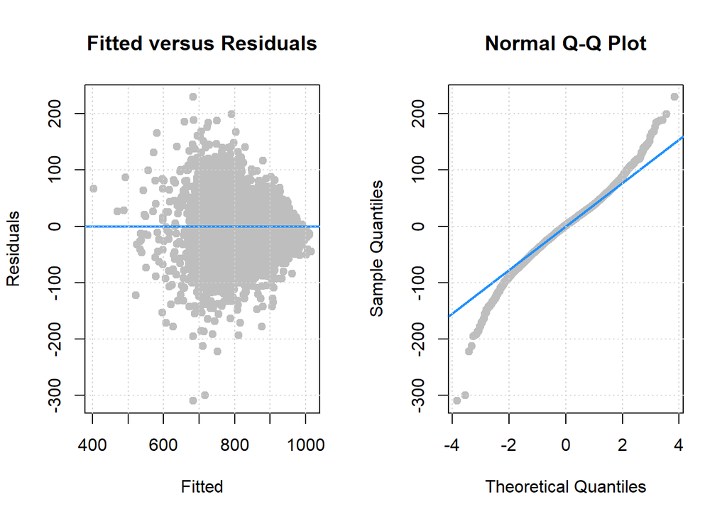

```
## $p_val_shapiro
## [1] 2.181e-24
##
## $decision_shapiro
## [1] "Fail Shapiro-Wilk test"
##
## $p_val_bp
##         BP
## 2.889e-134
##
## $decision_bp
##             BP
## "Fail BP test"
```

```r
diagnostics(mod_reduced)
```

After removing a few collinear predictors, we notice that the model’s adjusted r squared has not changed, but the assumptions are still violated.

We then try performing Box-Cox transformation of the response:

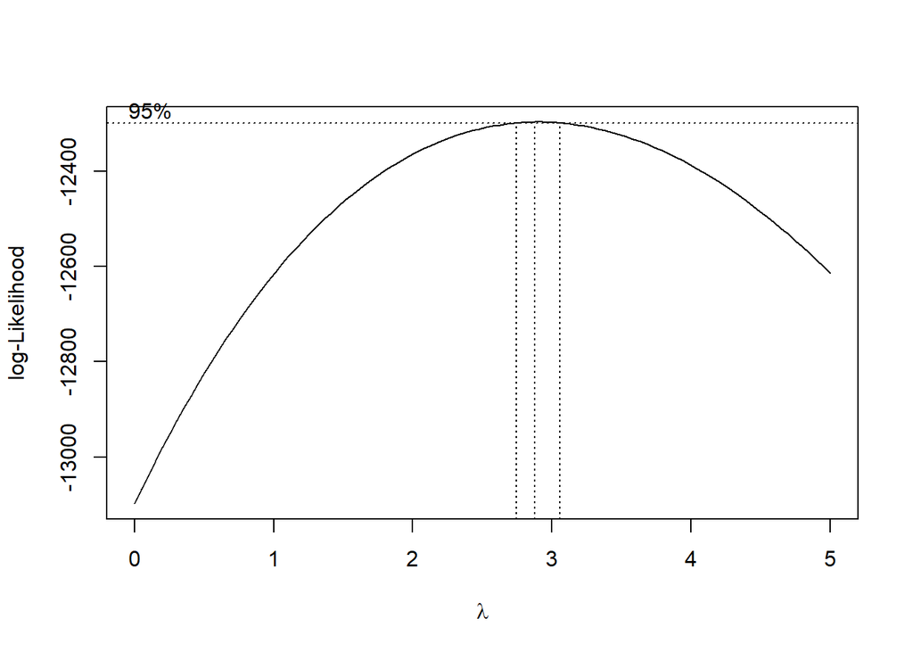

```r
boxcox(mod_reduced, plotit = TRUE, lambda = seq(0, 5, by = 0.1))
```

We find that the best lambda in this case 2.85.

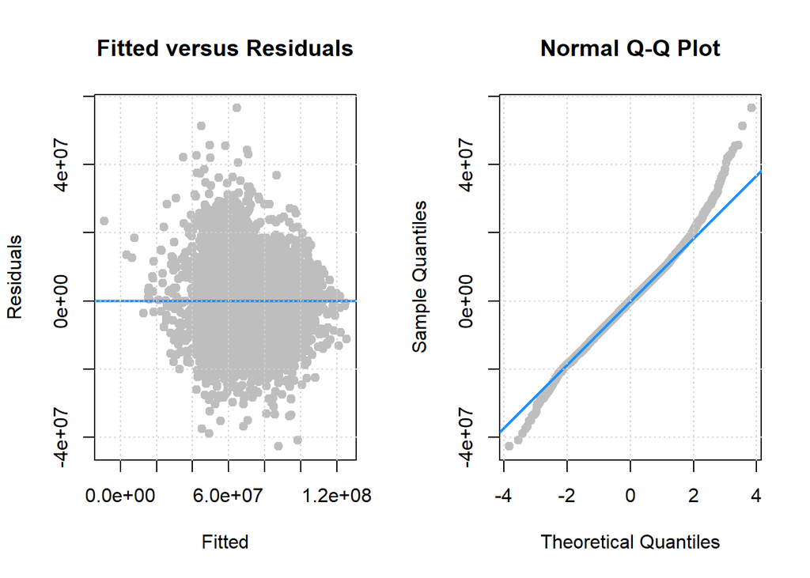

```
## $p_val_shapiro
## [1] 1.54e-17
##
## $decision_shapiro
## [1] "Fail Shapiro-Wilk test"
##
## $p_val_bp
##        BP
## 4.451e-86
##
## $decision_bp
##             BP
## "Fail BP test"
```

```r
lambda = 2.85
mod_cox = lm((API13 ^ lambda - 1)/lambda ~CHARTER + PCT_AA + PCT_AI + PCT_AS + PCT_HI + PCT_PI +
    P_GATE + P_MIGED + P_EL + P_RFEP + P_DI + CBMOB + NOT_HSG + HSG + COL_GRAD + GRAD_SCH + EMER, data = data_2013)
#summary(mod_cox)
diagnostics(mod_cox)
```

The plots look better, but the model still does not pass the formal tests.

We will then look at points with high leverage:

```r
sum(hatvalues(mod_cox) > 2 * mean(hatvalues(mod_cox)))
```

```
## [1] 599
```

```r
sum(abs(rstandard(mod_cox)) > 2)
```

```
## [1] 347
```

The numbers are fairly high, and it seems that removing influential overvations might help:

```r
cd = cooks.distance(mod_cox)
mod_new = lm(formula(mod_cox), data = data_2013, subset = cd < 4 / length(cd))
summary(mod_new)
```

```
##
## Call:
## lm(formula = formula(mod_cox), data = data_2013, subset = cd <
##     4/length(cd))
##
## Residuals:
##       Min        1Q    Median        3Q       Max
## -25417395  -5759607      9671   5709223  29877254
##
## Coefficients:
##             Estimate Std. Error t value Pr(>|t|)
## (Intercept) -9682076    2522853   -3.84  0.00013 ***
## CHARTERY     -180507     381730   -0.47  0.63632
## PCT_AA       -237979      12432  -19.14  < 2e-16 ***
## PCT_AI       -420502      62352   -6.74  1.7e-11 ***
## PCT_AS        252412      11258   22.42  < 2e-16 ***
## PCT_HI         96388       8693   11.09  < 2e-16 ***
## PCT_PI       -712152     113551   -6.27  3.8e-10 ***
## P_GATE         94686      11253    8.41  < 2e-16 ***
## P_MIGED      -246955      30578   -8.08  7.7e-16 ***
## P_EL          -51549      11262   -4.58  4.8e-06 ***
## P_RFEP       -214878      14212  -15.12  < 2e-16 ***
## P_DI         -215735      20585  -10.48  < 2e-16 ***
## CBMOB         801265      24163   33.16  < 2e-16 ***
## NOT_HSG      -204027      17063  -11.96  < 2e-16 ***
## HSG          -103472      20486   -5.05  4.5e-07 ***
## COL_GRAD      304648      21841   13.95  < 2e-16 ***
## GRAD_SCH      378036      13782   27.43  < 2e-16 ***
## EMER         -278703      32579   -8.55  < 2e-16 ***
## ---
## Signif. codes:  0 '***' 0.001 '**' 0.01 '*' 0.05 '.' 0.1 ' ' 1
##
## Residual standard error: 8360000 on 7491 degrees of freedom
## Multiple R-squared:  0.801,  Adjusted R-squared:  0.801
## F-statistic: 1.78e+03 on 17 and 7491 DF,  p-value: <2e-16
```

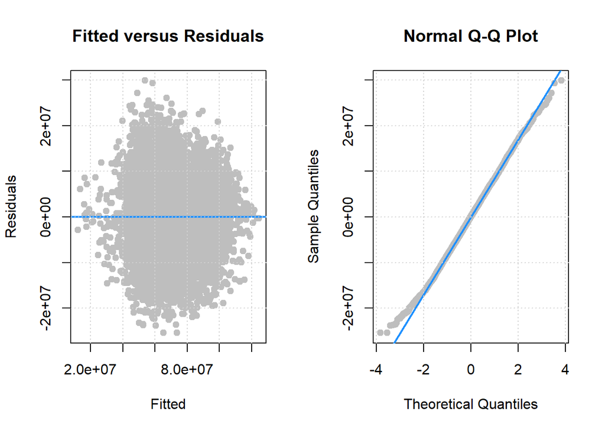

```
## $p_val_shapiro
## [1] 0.05518
##
## $decision_shapiro
## [1] "Pass Shapiro-Wilk test"
##
## $p_val_bp
##        BP
## 2.349e-15
##
## $decision_bp
##             BP
## "Fail BP test"
```

```r
diagnostics(mod_new, alpha = 0.01)
```

```r
vif(mod_new)
```

```
## CHARTERY   PCT_AA   PCT_AI   PCT_AS   PCT_HI   PCT_PI   P_GATE  P_MIGED
##    1.129    1.371    1.279    2.194    6.867    1.132    1.176    1.264
##     P_EL   P_RFEP     P_DI    CBMOB  NOT_HSG      HSG COL_GRAD GRAD_SCH
##    4.197    3.396    1.084    1.354    9.365    6.401    7.930    4.439
##     EMER
##    1.070
```

Removing points with large Cooks distance results in better plots; Shapiro-Wilk test now fails to reject the null at alpha = 0.01.

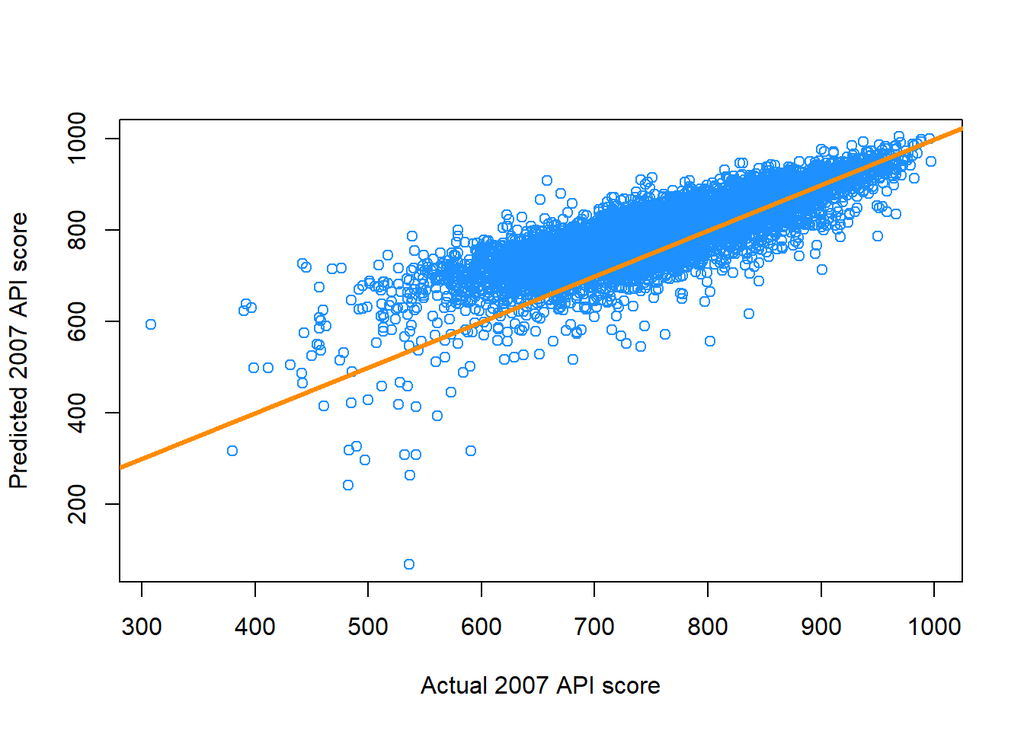

```r
# see how well we predict

nd = data.frame(CHARTER = data_2007$CHARTER, PCT_AA = data_2007$PCT_AA, PCT_AI = data_2007$PCT_AI, PCT_AS = data_2007$PCT_AS, PCT_HI = data_2007$PCT_HI, PCT_PI = data_2007$PCT_PI, P_GATE = data_2007$P_GATE, P_MIGED = data_2007$P_MIGED, P_EL= data_2007$P_EL, P_RFEP = data_2007$P_RFEP, P_DI = data_2007$P_DI, CBMOB = data_2007$CBMOB, HSG = data_2007$HSG, NOT_HSG = data_2007$NOT_HSG, COL_GRAD = data_2007$COL_GRAD, GRAD_SCH = data_2007$GRAD_SCH, EMER = data_2007$EMER)

pred_2007_transformed = predict(mod_new, newdata = nd)

#BEcause we transformed our response variable, we need to convert it back to the original scale.
pred_2007 = ( lambda * pred_2007_transformed + 1 ) ^ ( 1 / lambda )

plot(pred_2007 ~ data_2007$API07, col = "dodgerblue", xlab = "Actual 2007 API score", ylab = "Predicted 2007 API score")
abline(a = 0, b = 1, col = "darkorange", lwd = 3)
```

Our model based on data from 2013 does a fairly good job at predicting API scores, however, on the low end of API scores, there is significant amount of variance.

# Conclusions

Even though the bptest rejected the null hypothesis of a constant variance, the `Fitted vs Residual` plot doesn’t show any discernible patterns. The Shapiro test failed to reject the null hypothesis that the data was sampled from a normal distribution. The `vif()` check show slight collinearity for several predictors in the final model, with the highest VIF value of 9.3. The QQ-Plot looks good.

Again this model is not the only model that will fit. Since ethnicity have a collinearity issue (since all percentages add up to 100%), the model will pick a particular ethnicity depending on the data set. So these predictors are not obsolete.

We see that this model also predicts the student’s test score somewhat well in the 2007 data set.